# Introduction to Regression analysis in R

# 1. Simple Linear Regression with Numerical Predictor

Linear regression can help us understand how values of a quantitative (numerical) outcome (or response) are associated with values of a quantitative explanatory (or predictor) variable. This technique is often applied in two ways: to generate predicted values or to make inferences regarding associations in the dataset.

A simple linear regression model for an outcome $y$ as a function of a predictor $x$ takes the form:

$$\begin{align*}
y_i = \beta_0+\beta_1 x_i + \epsilon_i, \hspace{0.5cm} \text{for } i=1,...,n,
\end{align*}$$

where $(y_i,x_i)$ is the $i$th pair of observation for $(y,x)$ and $n$ is the number of observations. For this model, $\beta_0$ is the population parameter corresponding to the intercept (i.e., the predicted value when $x = 0$) and $\beta_1$ is the true (population) slope coefficient (i.e., the predicted increase in $y$ for a unit increase in $x$). The $\epsilon_i$’s are the errors (these are assumed to be random noise with mean $0$).

We almost never know the true values of the population parameters $\beta_0$ and $\beta_1,$ but we estimate them using data from our sample. The `lm()` function ﬁnds the “best” coefficients $\hat\beta_0$ and $\hat\beta_1$ where the the fitted values (or expected values) are given by $\hat y_i = \hat\beta_0 + \hat\beta_1x_i$. What is left over is captured by the residuals ($e_i= y_i - \hat y_i$). The model almost never fits perfectly—if it did there would be no need for a model.

## Example

We load the `Galton` dataset from the package `mosaicData`. Read the description of the dataset.

```r
#install.packages(c("mosaic","mosaicData")
library(mosaic)
library(mosaicData)
data("Galton")
```

### Your Turn 1

Fit a linear regression model of `height` on `father`. Store the fitted model into a variable called `fit`. Print the model summary. Predict the child height when the father’s height is 80 inches. Use the `predict()` function. Also predict the value using the coefficient estimates (i.e. $\hat y = \hat\beta_0 + \hat\beta_1x$). Do these two predicted values agree? (HINT: In `predict()`, `newdata` must be a `data.frame`)

## 1.1. Model Visualization

Often, a scatterplot for $y$ vs $x$ is plotted with the fitted line overlapped on the plot. This gives us a rough idea of how the regression line fits the data.

### Your Turn 2

Draw a scatterplot of `height` against `father` with the fitted regression line on the plot. Comment on the fit from the plot.

## 1.2. Measuring the strength of fit

There are several methods of evaluating the strength of a model fit. One popular method is to use coeeficient of determination $R^2$, which is defined as

$$\begin{align*}
R^2 = 1 - \frac{SSE}{SST},
\end{align*}$$

where $SSE=\sum\limits_{i=1}^n (y_i-\hat y_i)^2$ and $SST = (n-1) Var(y) = \sum\limits_{i=1}^n (y_i-\bar y)^2$. $R^2$ is always between $0$ and $1$, both inclusive. It is interpreted as the proportion of the total variation in the data that is explained by the fitted model with $R^2=0$ meaning the regression model fails to explain the variation in the data entirely whereas $R^2=1$ means complete explanation (or perfect fit). For real world data, it is impossible to get $R^2=1$, but the higher it is, the better is the model fit.

Note that $SSE = (n-1)Var(e) = \sum\limits_{i=1}^ne_i^2$. You can use the command `residuals()` to compute all the residuals.

### Your Turn 3

Find the value of $R^2$ for the fitted model using the command `summary(fit)$r.squared`. Also find the same by evaluating the formula above. Do the values agree?

### Your Turn 4

Split the dataset into two parts viz. one for the male children and the other for the female children. Fit two different linear regression models of `height` on `father` for each dataset and store them into two different variables viz. `fit_m` and `fit_f` respectively. Report the $R^2$ values for each model. Are the $R^2$ values higher than the $R^2$ value for the entire data? Comment on your findings.

# 2. Linear Regression with Categorical Predictor

Suppose that instead of using father’s height as our explanatory variable for child’s height, we only considered the sex of the child. The indicator variable `sex` is binary (or dichotomous) in that it only takes on two values “M” and “F”. We can code this into a dummy variable that takes the value 0 when sex is “M” and 1 for “F”. Note that this encoded variable is not exactly a numerical variable although it takes the values 0 and 1. This new linear regression model has the form:

$$height = \beta_0 + \beta_1 sex + \epsilon.$$

In R, you can either enter the categorical variable `sex` directly or encode it into a dummy variable of type `factor`.

```r
fit_cat=lm(height~sex,data=Galton)
summary(fit_cat)
```

```
##
## Call:
## lm(formula = height ~ sex, data = Galton)
##
## Residuals:
##     Min      1Q  Median      3Q     Max
## -9.2288 -1.6102 -0.1102  1.7712  9.7712
##
## Coefficients:
##             Estimate Std. Error t value Pr(>|t|)
## (Intercept)  64.1102     0.1206  531.70   <2e-16 ***
## sexM          5.1187     0.1676   30.55   <2e-16 ***
## ---
## Signif. codes:  0 '***' 0.001 '**' 0.01 '*' 0.05 '.' 0.1 ' ' 1
##
## Residual standard error: 2.509 on 896 degrees of freedom
## Multiple R-squared:  0.5102, Adjusted R-squared:  0.5096
## F-statistic: 933.2 on 1 and 896 DF,  p-value: < 2.2e-16
```

The $R^2$ value is much higher for this model implying that sex of a child has significant effect in their height.

### Your Turn 5

Create a dummy variable `ind`, which takes the value 0 when `sex` is “M” and 1 for “F”. Then use the command `ind=factor(ind)` to define it as a factor variable. Now fit a model of `height` on `ind` and see if you get the same model. If not the same, try to think of a reason.

# 3. Multiple Linear Regression

Multiple regression is a natural extension of simple linear regression that incorporates multiple explanatory (or predictor) variables. It has the general form:

$$\begin{align*}
y_j= \beta_0 + \beta_1x_{1j}+...+\beta_p{x_pj}+\epsilon_j,
\end{align*}$$
where $x_1,...,x_p$ are $p$ predictors with $x_{ij}$ being the $j$th observation of $x_i$, $j=1,...,n$ and $i=1,...,p$.

The estimated coefficients (i.e. $\beta_i$’s) are interpreted as “conditional on” the other variables — each $\beta_i$ reﬂects the predicted change in $y$ associated with a one-unit increase in $x_i$, conditional upon the rest of the xi’s. This type of model can help to disentangle more complex relationships between three or more variables. The value of $R^2$ from a multiple regression model has the same interpretation as before: the proportion of variability explained by the model.

## 3.1. Parallel Slopes: Multiple Regression with a Categorical Variable

Consider the case with $p=2$, where $x_1$ is numerical (e.g. father’s height) and $x_2$ is an indicator variable that can only be 0 or 1 (e.g. sex). Then

$$\begin{align*}
\hat y=\hat\beta_0 + \beta_1 x_1 + \beta_2 x_2.
\end{align*}$$

Note that

$$\begin{align*}
\hat y|_{x_1,x_2=0}&=\hat\beta_0 + \hat\beta_1 x_1\\
\hat y|_{x_1,x_2=0}&=\hat\beta_0 + \hat\beta_1 x_1 + \hat\beta_2\\
&=(\hat\beta_0+\hat\beta_2) + \hat\beta_1 x_1
\end{align*}$$

This is called a parallel slopes model, since the predicted values of the model take the geometric shape of two parallel lines with slope $\hat\beta_1$: one with y-intercept $\hat\beta_0$ for $x_2=0$, and another with y-intercept $\hat\beta_0+\hat\beta_2$ for $x_2=1$.

For example:

```r
mod_parallel <- lm(height~father+sex,data=Galton)
summary(mod_parallel)
```

```
##
## Call:
## lm(formula = height ~ father + sex, data = Galton)
##
## Residuals:
##     Min      1Q  Median      3Q     Max
## -9.3708 -1.4808  0.0192  1.5616  9.4153
##
## Coefficients:
##             Estimate Std. Error t value Pr(>|t|)
## (Intercept) 34.46113    2.13628   16.13   <2e-16 ***
## father       0.42782    0.03079   13.90   <2e-16 ***
## sexM         5.17604    0.15211   34.03   <2e-16 ***
## ---
## Signif. codes:  0 '***' 0.001 '**' 0.01 '*' 0.05 '.' 0.1 ' ' 1
##
## Residual standard error: 2.277 on 895 degrees of freedom
## Multiple R-squared:  0.5971, Adjusted R-squared:  0.5962
## F-statistic: 663.2 on 2 and 895 DF,  p-value: < 2.2e-16
```

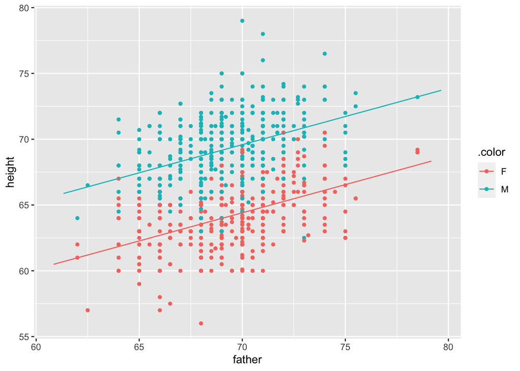

```r
plotModel(mod_parallel,system="ggplot2")
```

## 3.2. Parallel planes: Multiple regression with a second quantitative variable

If $x_2$ is a continuous variable, we have

$$\begin{align*}
\hat y = \hat\beta_0+\hat\beta_1x_1+\hat\beta_2x_2.
\end{align*}$$

Notice that our model is no longer a line, rather it is a plane that exists in three dimensions.

### Your Turn 6

Now, suppose that we want to improve our model for child height by considering not only the father’s height, but also the mother’s hieght. We can do this in R by simply adding this variable to our regression model. Fit such a linear regression model and plot its summary. Is there any improvement in $R^2$ value?

### Your Turn 7

Fit a bigger model of `height` on `father`, `mother` and `sex`. Print the summary and comment on the goodness of fit.

## 3.3. Non-parallel slopes: Multiple Regression with Interaction

Let’s return to a model that includes `father` and `sex` as predictors. What if the parallel slopes model doesn’t ﬁt well? Adding an additional term into the model can make it more ﬂexible and allow there to be a different slope on the two different types of days:

$$\begin{align*}
\hat y = \hat\beta_0 + \hat\beta_1 x_1 + \hat\beta_2 x_2 + \hat\beta_3 x_1x_2.
\end{align*}$$

We then have:

$$\begin{align*}
\hat y|_{x_1,x_2=0}&=\hat\beta_0 + \hat\beta_1 x_1\\
\hat y|_{x_1,x_2=0}&=\hat\beta_0 + \hat\beta_1 x_1 + \hat\beta_2+\hat\beta_3 x_1\\
&=(\hat\beta_0+\hat\beta_2) + (\hat\beta_1 + \hat\beta_3)x_1
\end{align*}$$

This is called an interaction model. The predicted values of the model take the geometric shape of two non-parallel lines with different slopes.

### Your Turn 8

Fit a model of `height` on `father`, `sex` and `father*sex` (the interaction term). Find the $R^2$ value and comment on it. Also plot the model and see if the lines have different slopes.

## 3.4. Modeling non-linear relationships

In some cases, the relation between $y$ and $x$ are non-linear. In those cases, adding higher order terms are useful. For example:

```r
fit_nl=lm(height~father+I(father^2),data=Galton)
summary(fit_nl)
```

```
##
## Call:
## lm(formula = height ~ father + I(father^2), data = Galton)
##
## Residuals:
##      Min       1Q   Median       3Q      Max
## -10.3293  -2.7561  -0.1598   2.6506  11.8467
##
## Coefficients:
##              Estimate Std. Error t value Pr(>|t|)
## (Intercept) -32.40156   56.80673  -0.570    0.569
## father        2.46214    1.63660   1.504    0.133
## I(father^2)  -0.01486    0.01178  -1.261    0.208
##
## Residual standard error: 3.445 on 895 degrees of freedom
## Multiple R-squared:  0.07746,    Adjusted R-squared:  0.0754
## F-statistic: 37.57 on 2 and 895 DF,  p-value: < 2.2e-16
```

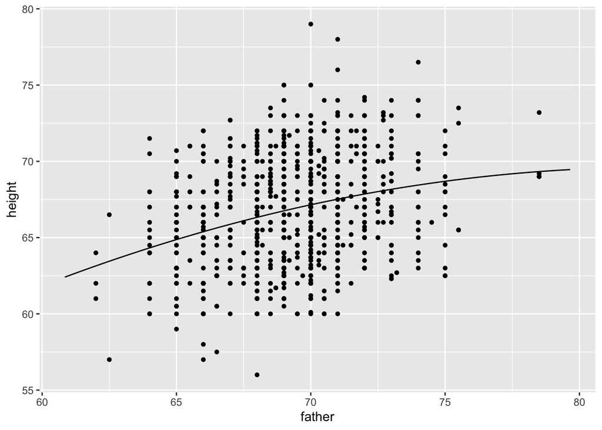

```r
plotModel(fit_nl)
```

Note how `I(father^2)` is used to add higher order terms.

If you keep on adding more response variable in a regression, the $R^2$ value will always increase. But adding more and more terms makes the model complex and unusable. Hence we keep on increasing the power by one and stop when the change in $R^2$ value is negligible.

### Your Turn 9

First fit a regression model of `height` on ‘father’ and `mother`. Add the term `mother^2` and note the difference in $R^2$. If you feel that this gain is very small, stop there and return the `height ~ father + mather` as the final model. Otherwise, keep on increasing the power of the variable `mother` until the gain is negligible.

### Your Turn 10

Check if adding `father*mother` interaction term in the final model, obtained in **Your Turn 9** increases the $R^2$ value by a good margin. Should we keep the interaction term?